# QTM490

Erin Sheena, Ritu Shah, Prerna Advani

4/15/2020

#Project

**The nature of the project we are proposing to undertake is analyzing voter turnout rates in jails for populations that are incarcerated before their trial. Therefore, they have not been convicted of a crime and are still eligible to vote in elections. The goal is to highlight the lack of accessibility and awareness for voter registration, i.e., being asked if they would like to register to vote, actually obtaining an absentee ballot, etc.**

## Background

**This project relates to representation in the political system of individuals that are incarcerated before trial but have not yet been convicted of a crime. This misrepresentation disproportionately affects lower income individuals and individuals of color, because poor people cannot afford bail and people of color are more likely to be given higher bails. This relates to feminist principles, because there is a huge imbalance in power of representation within our government. It is estimated that there are about 750,000 individuals in the United States that are incarcerated and awaiting trial. This can make a huge difference in who is and who is not elected to government. Further, the individuals that are elected have the capability to create reforms to our wildly biased criminal “justice” system. As stated before, the ones most affected by pre-trial bail are the ones who are least represented in our political system and are often overlooked or disproportionately targeted by our society.** **This project is important, because it will bring awareness to the lack of accessibility to voting for people that are incarcerated while awaiting trial. Awareness is the first step to making proactive changes to our society, and exposing the poor rates of voting within these systems will hopefully create a space for individuals to create voting centers, proactively give absentee ballots, etc. to these communities.**

# VDR Dataset

**Our dataset comes from the Houston Justice organization’s campaign called Project Orange, which works to increase voter registration for prison inmates and their families. It consists of data from 3 separate days in September 2018 during which VDRs from Harris county went to Harris County Jail to register people to vote.**

# Methods

## Import Data

```r
VDR_Project_Orange <- read.csv("https://raw.githubusercontent.com/prernaadvani/QTM-490-Final-Project/master/VDR_Project_Orange_Overall_1.csv")
```

## Clean

```r
#Remove unnecessary columns
VDR_Project_Orange$X9.16.18...Name = NULL
VDR_Project_Orange$VDR = NULL
VDR_Project_Orange$email = NULL
VDR_Project_Orange$Phone = NULL
VDR_Project_Orange$Kick.Outs = NULL
VDR_Project_Orange$X = NULL
VDR_Project_Orange$Voter.Turnout = NULL

#Rename Data
colnames(VDR_Project_Orange)[colnames(VDR_Project_Orange) == "Number.of.Registered.Voters"] <- "NumRegister"
colnames(VDR_Project_Orange)[colnames(VDR_Project_Orange) == "Number.of.Applications.Received"] <- "NumApp"
colnames(VDR_Project_Orange)[colnames(VDR_Project_Orange) == "Not.Valid.to.Register"] <- "InvalidApp"

#set as numeric
VDR_Project_Orange$NumRegister <- as.numeric(VDR_Project_Orange$NumRegister)
VDR_Project_Orange$NumApp <- as.numeric(VDR_Project_Orange$NumApp)
VDR_Project_Orange$InvalidApp <- as.numeric(VDR_Project_Orange$InvalidApp)

#Delete NA and empty
VDR_Project_Orange_1 = VDR_Project_Orange[rowSums(is.na(VDR_Project_Orange)) == 0,]
VDR_Project_Orange_1
```

```
##    NumRegister NumApp InvalidApp    Date
## 1            6     10          4 9/16/18
## 2           13     18          5 9/16/18
## 3            4      8          4 9/16/18
## 4            3      5          2 9/16/18
## 5            5     10          5 9/16/18
## 6           12     15          3 9/16/18
## 7            5     11          6 9/16/18
## 8           11     20          9 9/16/18
## 9            4      8          4 9/16/18
## 10           4      4          0 9/16/18
## 11           5      7          2 9/16/18
## 12           8     10          2 9/16/18
## 13           5      5          0 9/16/18
## 14          12     16          4 9/16/18
```

[output cut: 63 more lines]

# Voter Turnout & Sums Dataset

## Import data

```r
VoterTurnoutData <- read.csv("https://raw.githubusercontent.com/prernaadvani/QTM-490-Final-Project/master/VoterTurnoutData_1.csv")
```

## Clean

```r
#Clean
names(VoterTurnoutData)[names(VoterTurnoutData) == "Number.of.Registered.Voters"] <- "NumRegister"
names(VoterTurnoutData)[names(VoterTurnoutData) == "Number.of.Applications.Received"] <- "NumApp"
names(VoterTurnoutData)[names(VoterTurnoutData) == "Not.Valid.to.Register"] <- "InvalidApp"
names(VoterTurnoutData)[names(VoterTurnoutData) == "Voter.Turnout"] <- "VoterTurnout"

VoterTurnoutData_1 <- select(VoterTurnoutData, "NumRegister", "NumApp", "InvalidApp", "VoterTurnout", "Date") %>%
  na.omit(VoterTurnoutData_1)
VoterTurnoutData_1
```

```
##   NumRegister NumApp InvalidApp VoterTurnout    Date
## 1         189    293        104           35 9/16/18
## 2          96    149         53           21 9/22/18
## 3         412    537        125          180 9/30/18
```

## Application Accepted Data

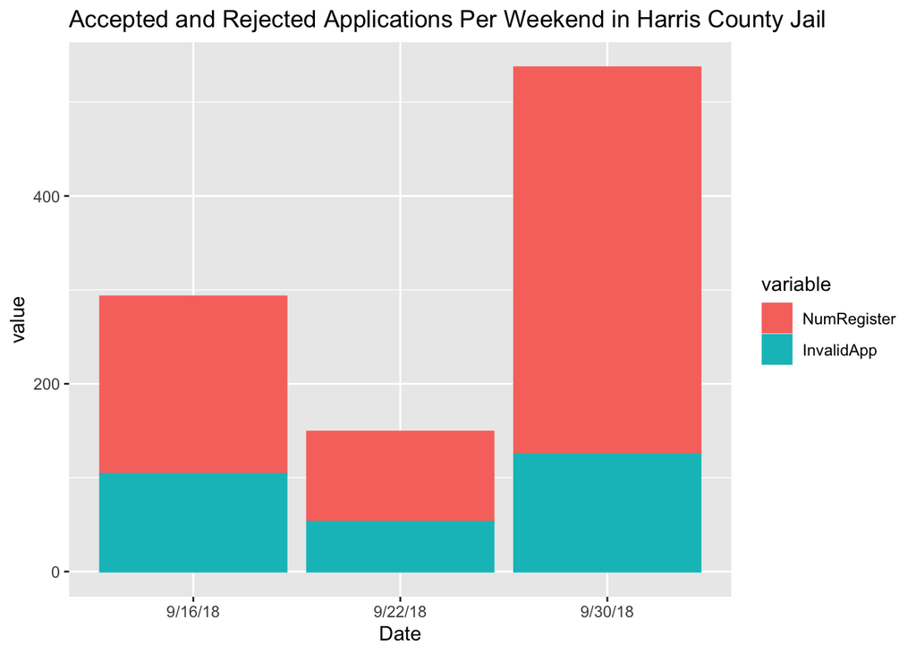

```r
#Graph for accepted applications
VoterTurnoutData_2 <- melt(VoterTurnoutData_1, id.var=c("Date", "VoterTurnout", "NumApp"))
ggplot(data=VoterTurnoutData_2, aes(x=Date, y=value, fill = variable, color = variable)) +
  geom_bar(stat="identity") + labs(title = "Accepted and Rejected Applications Per Weekend in Harris County Jail")
```

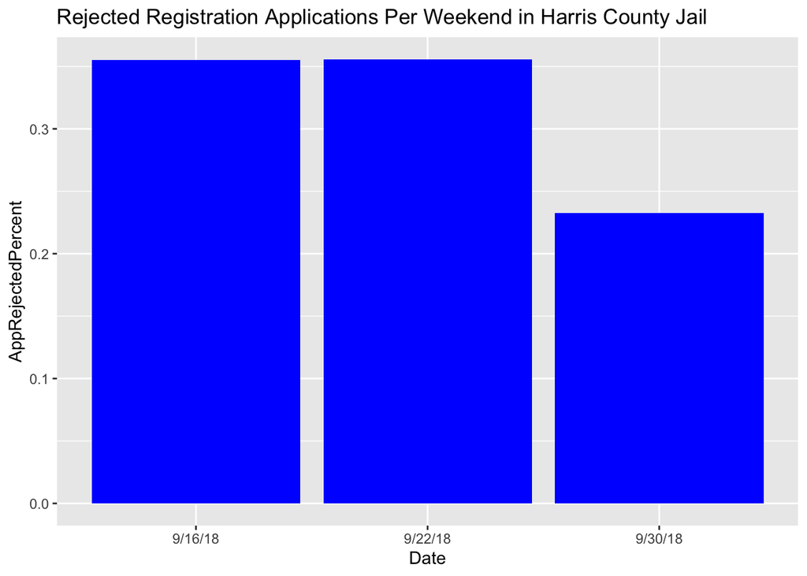

```r
#Graph for rejected applications
VoterTurnoutData_3 <- VoterTurnoutData_1 %>%
  group_by(Date) %>%
  mutate(AppRejectedPercent = InvalidApp / NumApp)

ggplot(data=VoterTurnoutData_3, aes(x=Date, y=AppRejectedPercent)) +
  geom_bar(stat="identity", fill="blue") +
  labs(title = "Rejected Registration Applications Per Weekend in Harris County Jail")
```

## Voter Turnout Data

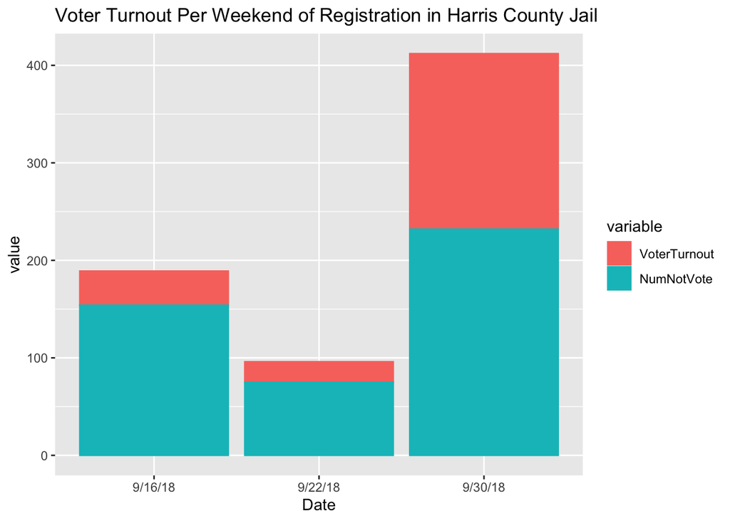

```r
#Voter turnout graph
VoterTurnoutData_4 <- VoterTurnoutData_1 %>%
  mutate(NumNotVote = NumRegister - VoterTurnout)
VoterTurnoutData_5 <- melt(VoterTurnoutData_4, id.var=c("Date", "InvalidApp", "NumApp", "NumRegister"))
ggplot(data=VoterTurnoutData_5, aes(x=Date, y=value, fill = variable, color = variable)) +
  geom_bar(stat="identity") + labs(title = "Voter Turnout Per Weekend of Registration in Harris County Jail")
```

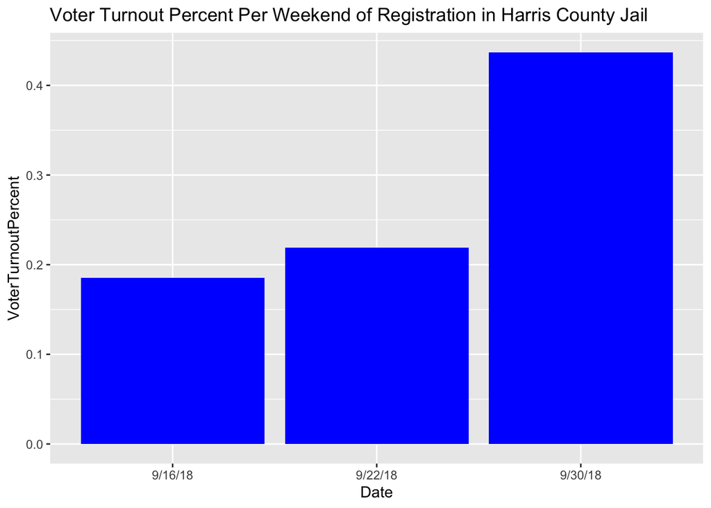

```r
#Voter turnout graph
VoterTurnoutData_6 <- VoterTurnoutData_1 %>%
  group_by(Date) %>%
  mutate(VoterTurnoutPercent = VoterTurnout / NumRegister)

ggplot(data=VoterTurnoutData_6, aes(x=Date, y=VoterTurnoutPercent)) +
  geom_bar(stat="identity", fill="blue") +
  labs(title = "Voter Turnout Percent Per Weekend of Registration in Harris County Jail")
```

# Historic Harris Country Voter Registration Figures

```r
#Data
HC_VT = read.csv("https://raw.githubusercontent.com/prernaadvani/QTM-490-Final-Project/master/Harris%20County%20Voter%20Registration%20Figures.csv")
names(HC_VT)[names(HC_VT) == "Voted.."] <- "VotedPercent"
HC_VT = HC_VT[complete.cases(HC_VT),]
```

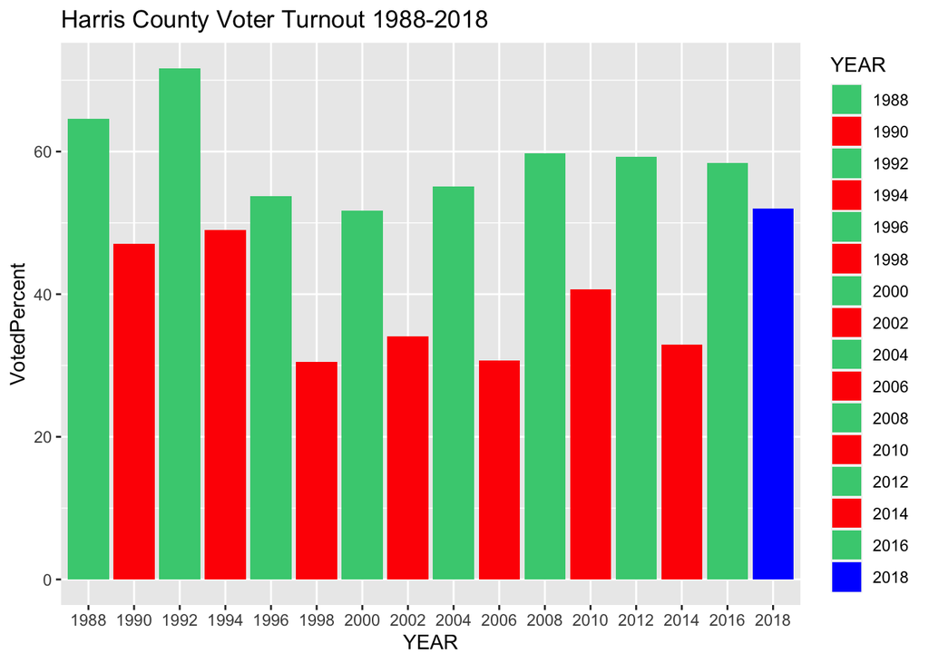

```r
#Graph
HC_VT$YEAR <- as.character(HC_VT$YEAR)
cols <- c("2018" = "blue", "2014" = "red", "2010" = "red", "2012" = "seagreen3", "2016" = "seagreen3", "2008" = "seagreen3", "1988" = "seagreen3", "1990" = "red", "1992" = "seagreen3", "1994" = "red", "1996" = "seagreen3", "1998" = "red", "2000" = "seagreen3", "2002" = "red", "2004" = "seagreen3", "2006" = "red")

ggplot(HC_VT, aes(x = YEAR, y = VotedPercent, fill = YEAR)) +
  geom_bar(stat = "identity") +
  scale_fill_manual(values = cols) +
  labs(title = "Harris County Voter Turnout 1988-2018")
```

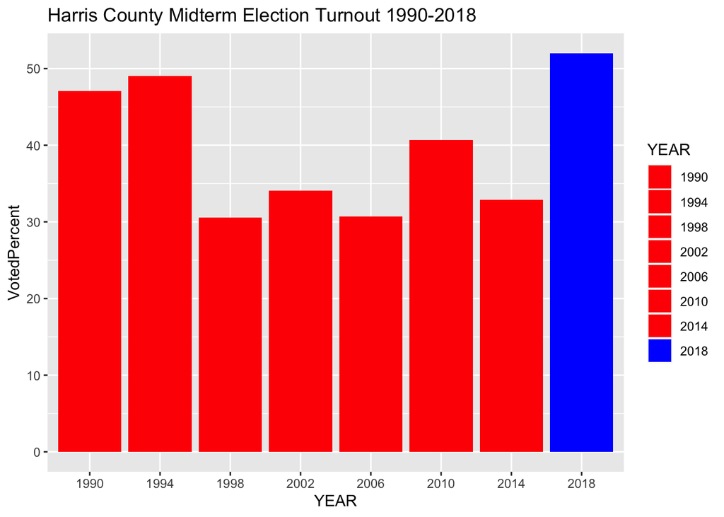

```r
#Graph with data from midterm elections

HC_ME = HC_VT %>% filter(`YEAR` == "2018" | `YEAR` == "2014" | `YEAR` == "2010" | `YEAR` == "2006" | `YEAR` == "2002" | `YEAR` == "1998" | `YEAR` == "1994" | `YEAR` == "1990")
new_cols = c("2018" = "blue", "2014" = "red", "2010" = "red", "2006" = "red", "2002" = "red", "1998" = "red", "1994" = "red", "1990" = "red")
ggplot(HC_ME, aes(YEAR, VotedPercent, fill = YEAR)) +
  geom_bar(stat = "identity") +
  scale_fill_manual(values = new_cols) +
  labs(title = "Harris County Midterm Election Turnout 1990-2018")
```

# Historic Texas Voter Turnout Figures

```r
#Data
TXVTbyYear <- read.csv("https://raw.githubusercontent.com/prernaadvani/QTM-490-Final-Project/master/State%20of%20Texas%20Voter%20Turnout%201988-Present.csv")
```

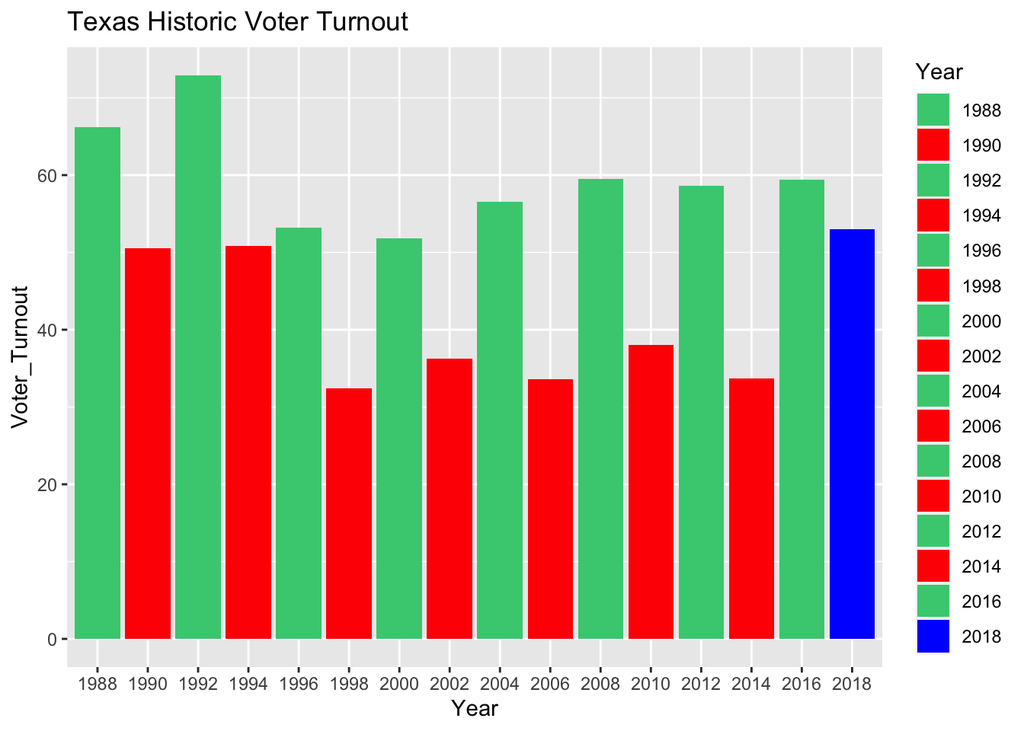

```r
#Graph
TXVTbyYear$Year <- as.character(TXVTbyYear$Year)
cols_tx <- c("2018" = "blue", "2014" = "red", "2010" = "red", "2012" = "seagreen3", "2016" = "seagreen3", "2008" = "seagreen3", "1988" = "seagreen3", "1990" = "red", "1992" = "seagreen3", "1994" = "red", "1996" = "seagreen3", "1998" = "red", "2000" = "seagreen3", "2002" = "red", "2004" = "seagreen3", "2006" = "red")

ggplot(TXVTbyYear, aes(x = Year, y = Voter_Turnout, fill = Year)) +
  geom_bar(stat = "identity") +
  scale_fill_manual(values = cols_tx) +
  labs(title = "Texas Historic Voter Turnout")
```

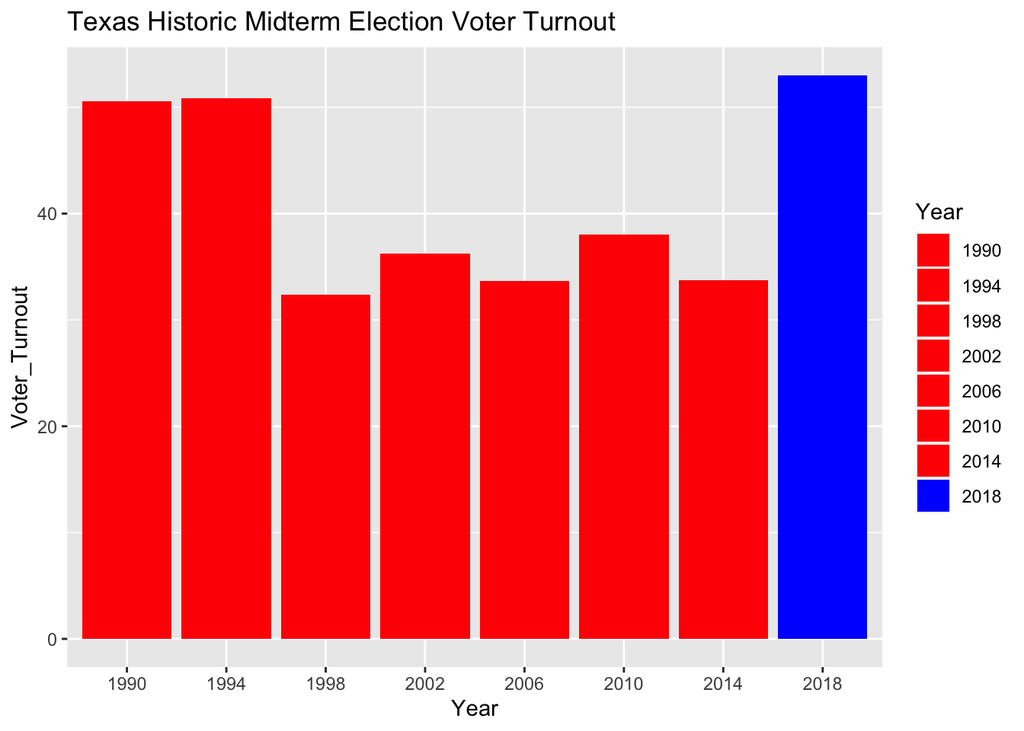

```r
#Graph with midterm elections

TXVTbyYear1 = TXVTbyYear %>% filter(`Year` == "2018" | `Year` == "2014" | `Year` == "2010" | `Year` == "2006" | `Year` == "2002" | `Year` == "1998" | `Year` == "1994" | `Year` == "1990")
cols_tx1 = c("2018" = "blue", "2014" = "red", "2010" = "red", "2006" = "red", "2002" = "red", "1998" = "red", "1994" = "red", "1990" = "red")
ggplot(TXVTbyYear1, aes(Year, Voter_Turnout, fill = Year)) +
  geom_bar(stat = "identity") +
  scale_fill_manual(values = cols_tx1) +
  labs(title = "Texas Historic Midterm Election Voter Turnout")
```

```r
#Graph comparing Texas Historic data to Harris County Historic data

TXVTbyYear2 = TXVTbyYear
Variable = "Texas"
colnames(TXVTbyYear2)[colnames(TXVTbyYear2) == "Voter_Turnout"] = "VotedPercent"
TXVTbyYear2 = cbind(TXVTbyYear2, Variable)
TXVTbyYear2 = as.data.frame(TXVTbyYear2)

Year = HC_VT$YEAR
VotedPercent = HC_VT$VotedPercent
Variable = "Harris"
HC_VT2 = cbind(Year, VotedPercent, Variable)
HC_VT2 = as.data.frame(HC_VT2)
HC_VT2$VotedPercent = as.numeric(as.character(HC_VT2$VotedPercent))

comb = merge(TXVTbyYear2, HC_VT2, all = TRUE)
comb <- comb %>%
  group_by(Year)
comb
```

```
## # A tibble: 32 x 3
## # Groups:   Year [16]
##    Year  VotedPercent Variable
##    <chr>        <dbl> <fct>
##  1 1988          64.6 Harris
##  2 1988          66.2 Texas
##  3 1990          47.1 Harris
##  4 1990          50.6 Texas
##  5 1992          71.7 Harris
##  6 1992          72.9 Texas
##  7 1994          49.0 Harris
##  8 1994          50.9 Texas
##  9 1996          53.2 Texas
## 10 1996          53.7 Harris
## # … with 22 more rows
```

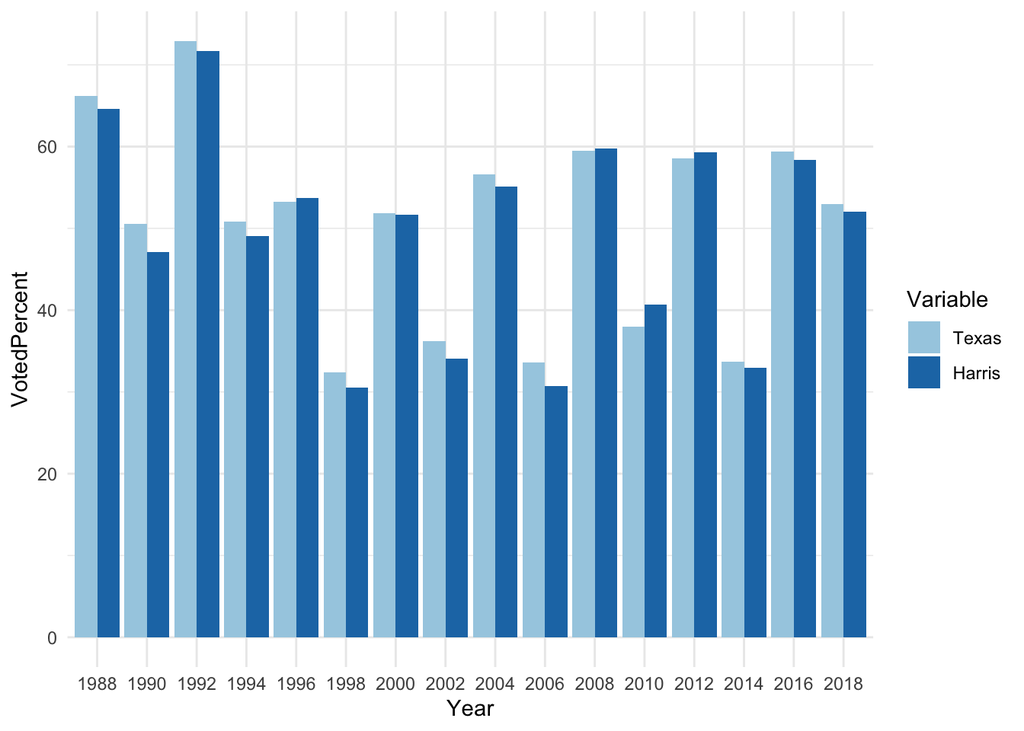

```r
ggplot(comb, aes(Year, VotedPercent, fill = Variable)) +
  geom_bar(stat = "identity", position=position_dodge()) +
  scale_fill_brewer(palette="Paired")+
  theme_minimal()
```

# 2018 Texas Voter Turnout Data in the context of eligible voters

```r
#Note: VAP is an acronym for Voting Age Population
TXVT = read.csv("https://raw.githubusercontent.com/prernaadvani/QTM-490-Final-Project/master/Texas%20Voter%20Eligibility%20and%20Turnout.csv")
TXVT
```

```
##                            Variable       Value
## 1                 Registered Voters  15,793,257
## 2       Voting Age Population (VAP) 19,900,980
## 3      Percentage of VAP Registered       79.36
## 4                          Turnout   8,371,655
## 5 Percent of Turnout to Registered        53.01
## 6         Percent of Turnout to VAP       42.07
```

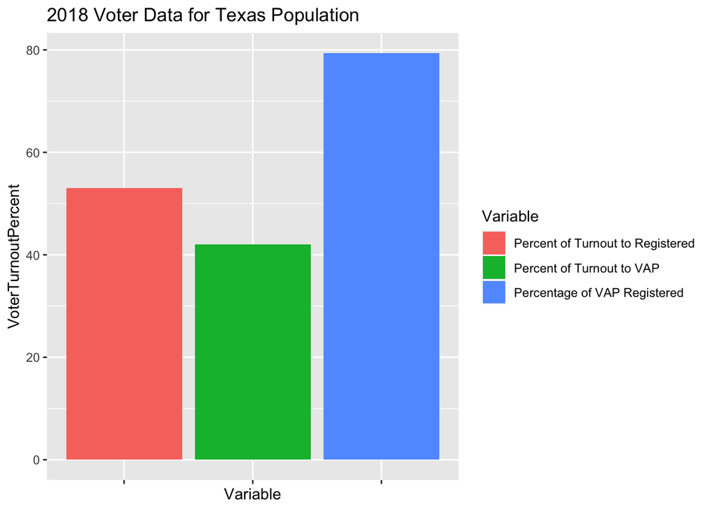

```r
#graph
colnames(TXVT)[colnames(TXVT) == "Value"] = "VoterTurnoutPercent"
TXVT$VoterTurnoutPercent = as.numeric(as.character(TXVT$VoterTurnoutPercent))
TXVT1 = filter(TXVT, grepl('Percent', Variable))
ggplot(TXVT1, aes(Variable, VoterTurnoutPercent, fill = Variable)) +
  geom_bar(stat = "identity") +
  theme(axis.text.x = element_blank()) +
  labs(title = "2018 Voter Data for Texas Population")
```

```r
#2018 Harris County Voter Turnout data compared to Harris County jail Voter Turnout

HCJ1 = VoterTurnoutData_6
HCJ1 = HCJ1[, -c(1:4)]
HCJ1$VoterTurnoutPercent = HCJ1$VoterTurnoutPercent *100
HCJ1
```

```
## # A tibble: 3 x 2
## # Groups:   Date [3]
##   Date    VoterTurnoutPercent
##   <fct>                 <dbl>
## 1 9/16/18                18.5
## 2 9/22/18                21.9
## 3 9/30/18                43.7
```

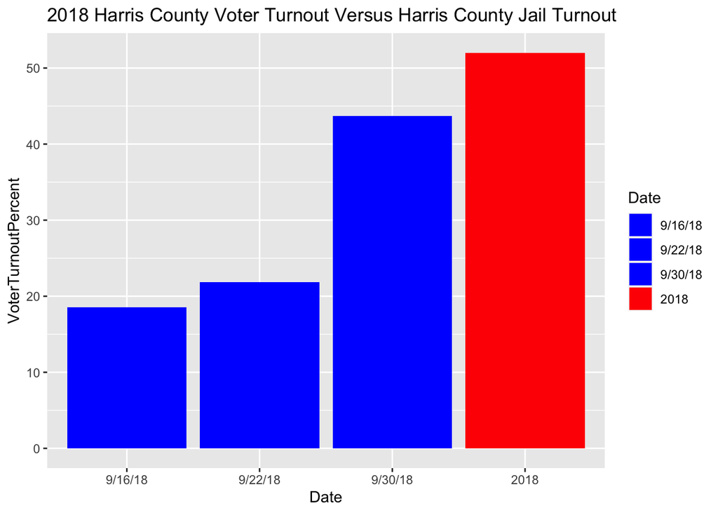

```r
HC2 = HC_ME %>% filter(YEAR == "2018")
HC2 = HC2[, -c(2,3,5,6)]

colnames(HC2)[colnames(HC2) == "VotedPercent"] <- "VoterTurnoutPercent"
colnames(HC2)[colnames(HC2) == "YEAR"] <- "Date"

newdat = merge(HCJ1, HC2, all=TRUE)

cols1 = c("blue","blue", "blue", "red")
ggplot(newdat, aes(Date, VoterTurnoutPercent, fill = Date)) +
  geom_bar(stat = "identity") +
  scale_fill_manual(values = cols1) +
  labs(title = "2018 Harris County Voter Turnout Versus Harris County Jail Turnout")
```

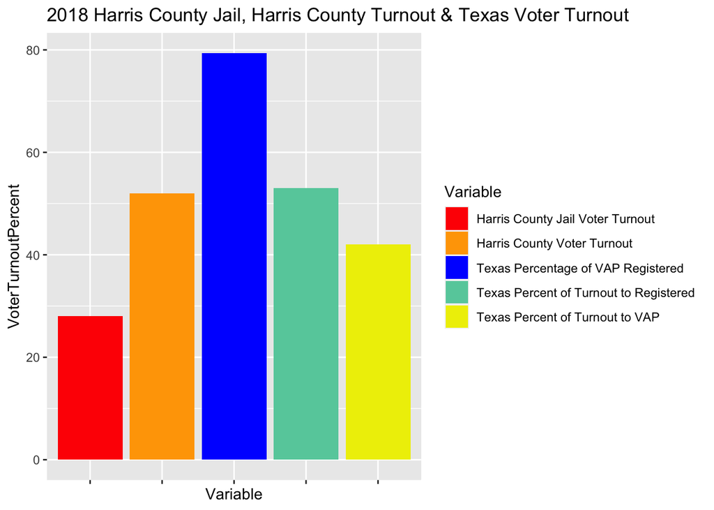

```r
#2018 Harris County Jail and Harris County Turnout compared to Texas

#Harris County Jail - 2018
VoterTurnoutPercent = mean(HCJ1$VoterTurnoutPercent)
Variable = "Harris County Jail Voter Turnout"
HCJ2 = cbind(Variable, VoterTurnoutPercent)
HCJ2 = as.data.frame(HCJ2)
HCJ2$VoterTurnoutPercent = as.numeric(as.character(HCJ2$VoterTurnoutPercent))

#Harris County - 2018
HC3 = HC2
HC3$Date = NULL
Variable = "Harris County Voter Turnout"
HC3 = cbind(HC3, Variable)

#Texas - 2018
TXVT2 = TXVT1
TXVT2$Variable = paste("Texas", TXVT2$Variable, sep=" ")

cols2 = c("red","orange", "blue", "aquamarine3", "yellow2")

newdat1 = merge(HCJ2, HC3, all = TRUE)
newdat = merge(newdat1, TXVT2, all=TRUE)

ggplot(newdat, aes(Variable, VoterTurnoutPercent, fill = Variable)) +
  geom_bar(stat = "identity") +
  scale_fill_manual(values = cols2) +
  theme(axis.text.x = element_blank()) +
  labs(title = "2018 Harris County Jail, Harris County Turnout & Texas Voter Turnout")
```

# Interpretation

**Preliminary data indicates that there were a large number of voter registration applications that were rejected. Weekend 1, 104 applications were rejected, while Weekend 2 and 3 had 53 and 125 applications respectively. Compared to the total number of applications, Weekend 1 had a rejection rate of 35.49%. Weekend 2 had a rejection rate of 35.57%, and weekend 3 had a rejection rate of 23.27%. The weighted overall rejection rate was then 28.80%. For actual voter turnout, for the Weekend 1 group had a turnout of 35 applications or a rate of 18.51%, while Weekends 2 and 3 had turnouts of 21 and 180 respectively, making their turnout rates 21.85% and 43.68%. Thus, the weighted overall turnout was 33.85%. This data is limited to one non-profit that registers voters in one jail. Thus, we must contextualize the data. This can be done in a couple of different ways. First, we must look at the total number of voters within the jail to see how many people were registered (or attempted to be registered) compared to the whole. Further, we must compare this data to data for other individuals that are not incarcerated (i.e. comparing data to the rest of the state).** **Additionally, this project can be extended to include other counties, metros and states. Although Project Orange specifically looked at Harris County, the next step for this project would be to collect data on rates of voting restrictions for people held in pre-trial incarceration in other counties within the Houston area. After keeping a running datasheet from the Houston metroplex, it could then be expanded to other major cities like Dallas and Austin, then to Texas, and then other states in the US. This could be done using a similar method of sending VDRs to the county jails and register inmates to vote.**